Adam Prado Pace U. Data Science 3/30/24

## Chapter 6 Applied #8

Applied #8)

Downloads all of the libraries. I’m not sure if I needed all of them, but just to be safe I included all of them from the lab here again.

```r
library(ISLR2)
library(leaps)
library(glmnet)
library(pls)
```

1. Creata 100 predictor variables, X. And a noise variable called noise

```r
set.seed(1)
X <- rnorm(100)
noise <- rnorm(100)
```

2. This creates a responce vector, Y. I chose the constants of 6,5,4, and 3 for B0 to B3 respectively.

```r
Y <- 6+ 5*X + 4*X^2 + 3*X^3 + noise
Y
```

```
##   [1]   3.0795970   7.1138120   1.9535398  36.4937062   7.5345850   4.7006787
##   [7]  10.4516216  13.9897254  11.1618451   6.4428390  32.4305459   8.2732249
##  [13]   5.1505543 -18.6932286  20.7498497   5.3903280   5.6000916  16.5257587
##  [19]  14.9594165  10.8314917  15.7952897  15.1360547   6.1817290 -11.9149327
##  [25]  11.2500552   6.4440939   5.2332025  -2.2831547   3.5141444   8.6831501
##  [31]  27.7620073   4.9361702   9.2458000   4.2236934  -0.8274931   2.8630476
##  [37]   4.1655380   5.1885994  19.6815317  13.4222367   3.3579347   6.1177520
##  [43]  10.7785427  10.0767675   2.3576342   2.6514940  10.5871371  13.5844171
##  [49]   4.1982011  13.9224825   9.2639550   3.7318617   7.9720614   0.2042906
##  [55]  28.7202732  53.8160309   5.5547666   1.1039283   9.3172527   7.2595865
##  [61]  83.0601819   5.5711307  13.3945520   7.0296358   2.6423360   9.3128212
##  [67]  -7.8893099  29.9380645   6.7266116  66.7173177  11.9125147   3.4986760
##  [73]  11.6859557   2.2974043  -0.2263994   7.8365359   5.0958802   8.0807767
##  [79]   7.4224382   5.0358061   2.6671741   6.3736851  22.5670775  -4.4098256
##  [85]  11.5304249   8.0601496  20.9052981   3.9986734   8.1195202   6.7519174
##  [91]   3.8085713  23.5637661  21.1439674  13.3225805  34.7853784   9.5146637
##  [97]   1.3356076   2.8671762   0.7780492   3.8300746
```

3. Uses regsubsets to perform best subset selection for a model containing x^1 to X^10

```r
DataSet <- data.frame(X = X, X2 = X^2, X3 = X^3, X4 = X^4, X5 = X^5, X6 = X^6, X7 = X^7, X8 = X^8, X9 = X^9, X10 = X^10, Y = Y)
regfit <- regsubsets(Y~., data=DataSet, nvmax=10)
summary(regfit)
```

```
## Subset selection object
## Call: regsubsets.formula(Y ~ ., data = DataSet, nvmax = 10)
## 10 Variables  (and intercept)
##     Forced in Forced out
## X       FALSE      FALSE
## X2      FALSE      FALSE
## X3      FALSE      FALSE
## X4      FALSE      FALSE
## X5      FALSE      FALSE
## X6      FALSE      FALSE
## X7      FALSE      FALSE
## X8      FALSE      FALSE
## X9      FALSE      FALSE
## X10     FALSE      FALSE
## 1 subsets of each size up to 10
## Selection Algorithm: exhaustive
##           X   X2  X3  X4  X5  X6  X7  X8  X9  X10
## 1  ( 1 )  " " " " "*" " " " " " " " " " " " " " "
## 2  ( 1 )  " " "*" "*" " " " " " " " " " " " " " "
## 3  ( 1 )  "*" "*" "*" " " " " " " " " " " " " " "
## 4  ( 1 )  "*" "*" "*" " " "*" " " " " " " " " " "
## 5  ( 1 )  "*" "*" "*" " " "*" "*" " " " " " " " "
## 6  ( 1 )  "*" "*" "*" " " " " " " "*" "*" "*" " "
## 7  ( 1 )  "*" "*" "*" " " "*" "*" " " "*" " " "*"
## 8  ( 1 )  "*" "*" "*" "*" " " "*" " " "*" "*" "*"
## 9  ( 1 )  "*" "*" "*" "*" "*" "*" " " "*" "*" "*"
## 10  ( 1 ) "*" "*" "*" "*" "*" "*" "*" "*" "*" "*"
```

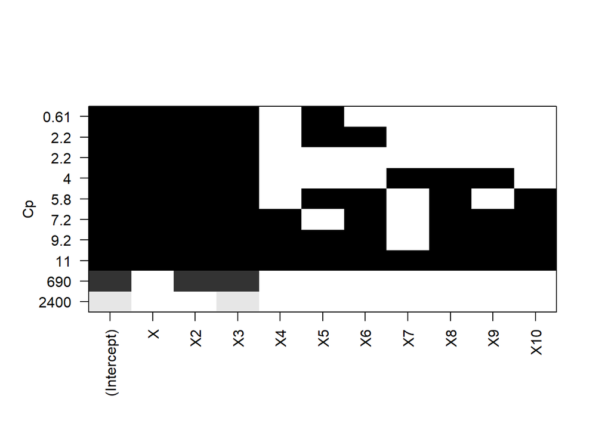

```r
plot(regfit, scale = "Cp")
```

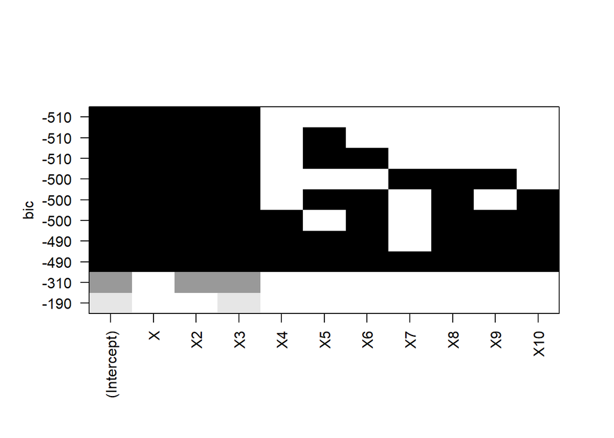

```r
plot(regfit, scale = "bic")
```

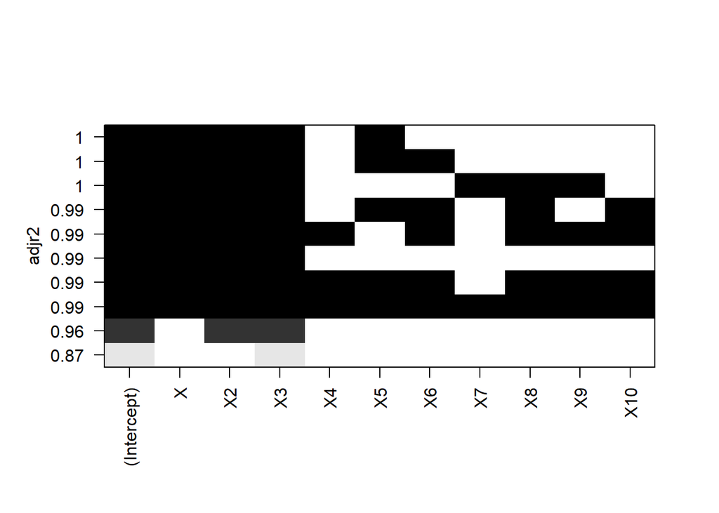

```r
plot(regfit, scale = "adjr2")
```

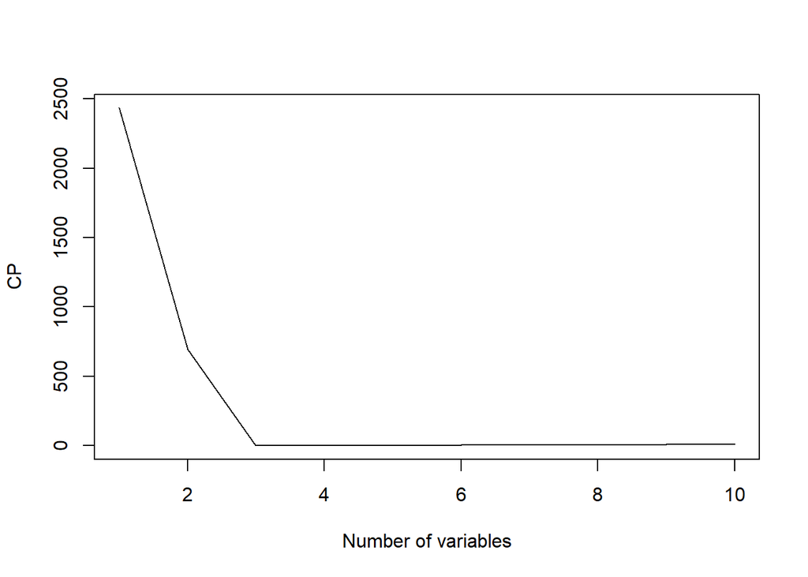

```r
regSummary <- summary(regfit)
plot(regSummary$cp, xlab = "Number of variables", ylab = "CP", type = "l")
```

```r
bestCp <- which.min(regSummary$cp)
bestCp
```

```
## [1] 4
```

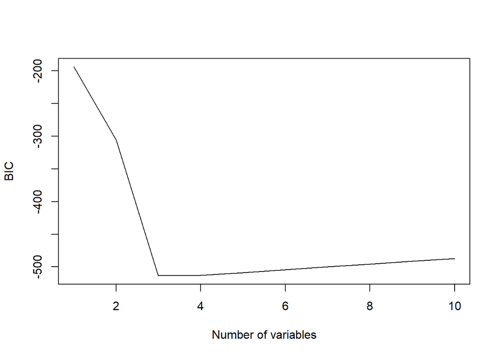

```r
plot(regSummary$bic, xlab = "Number of variables", ylab = "BIC", type = "l")
```

```r
bestBIC <- which.min(regSummary$bic)
bestBIC
```

```
## [1] 3
```

```r
coef(regfit, id=3)
```

```
## (Intercept)           X          X2          X3
##    6.061507    4.975280    3.876209    3.017639
```

```r
plot(regSummary$adjr2, xlab = "Number of variables", ylab = "Adjusted R2", type = "l")
```

[output not shown]

```r
bestAdjR2 <- which.max(regSummary$adjr2)
bestAdjR2
```

```
## [1] 4
```

```r
coef(regfit, id=4)
```

```
## (Intercept)           X          X2          X3          X5
##  6.07200775  5.38745596  3.84575641  2.55797426  0.08072292
```

3. The CP, BIC, and AdjR2 recommend using 3 or 4 variables. All three of them include x, x^2 and x^3 which is to be expcted because it’s how the model was created. Some of them use an extra variables x^5 but the coefficient of it is rather close to 0.  
   The coefficients of the other values are all relatively close to the expected values of 6,5,4 and 3.
4. Repeated the stepts above using forward and then backwards stepwise selection.

```r
regfitFwd <- regsubsets(Y~., data=DataSet, nvmax=10, method="forward")
regFwdSum <- summary(regfitFwd)
regFwdSum
```

```
## Subset selection object
## Call: regsubsets.formula(Y ~ ., data = DataSet, nvmax = 10, method = "forward")
## 10 Variables  (and intercept)
##     Forced in Forced out
## X       FALSE      FALSE
## X2      FALSE      FALSE
## X3      FALSE      FALSE
## X4      FALSE      FALSE
## X5      FALSE      FALSE
## X6      FALSE      FALSE
## X7      FALSE      FALSE
## X8      FALSE      FALSE
## X9      FALSE      FALSE
## X10     FALSE      FALSE
## 1 subsets of each size up to 10
## Selection Algorithm: forward
##           X   X2  X3  X4  X5  X6  X7  X8  X9  X10
## 1  ( 1 )  " " " " "*" " " " " " " " " " " " " " "
## 2  ( 1 )  " " "*" "*" " " " " " " " " " " " " " "
## 3  ( 1 )  "*" "*" "*" " " " " " " " " " " " " " "
## 4  ( 1 )  "*" "*" "*" " " "*" " " " " " " " " " "
## 5  ( 1 )  "*" "*" "*" " " "*" "*" " " " " " " " "
## 6  ( 1 )  "*" "*" "*" " " "*" "*" " " " " "*" " "
## 7  ( 1 )  "*" "*" "*" " " "*" "*" "*" " " "*" " "
## 8  ( 1 )  "*" "*" "*" " " "*" "*" "*" "*" "*" " "
## 9  ( 1 )  "*" "*" "*" " " "*" "*" "*" "*" "*" "*"
## 10  ( 1 ) "*" "*" "*" "*" "*" "*" "*" "*" "*" "*"
```

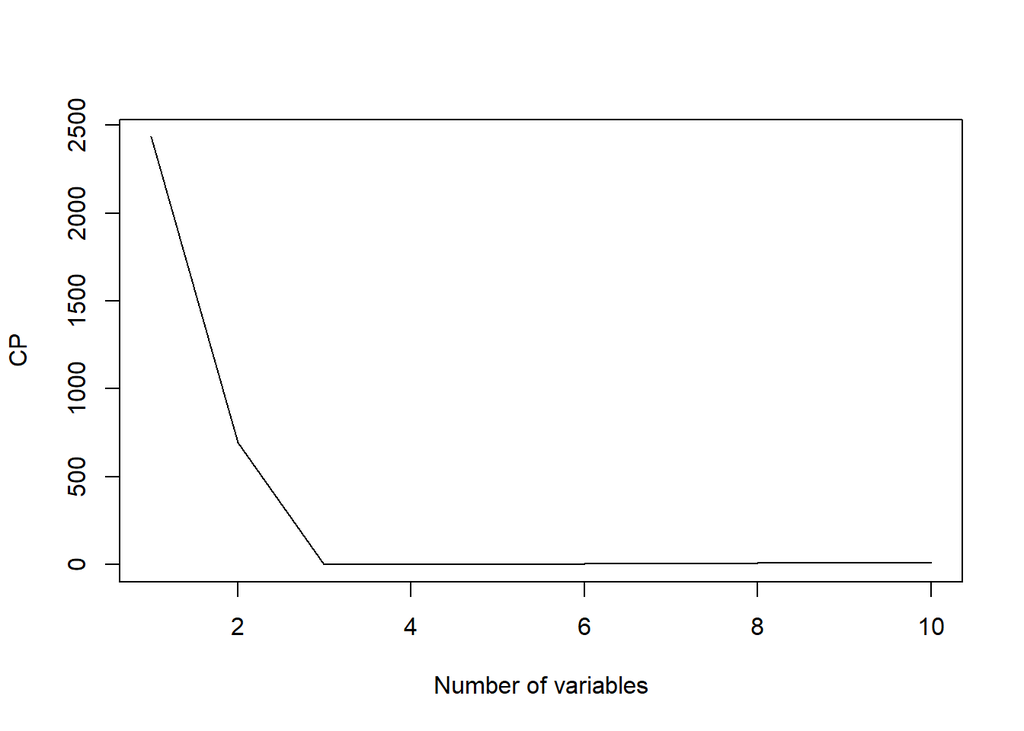

```r
plot(regFwdSum$cp, xlab = "Number of variables", ylab = "CP", type = "l")
```

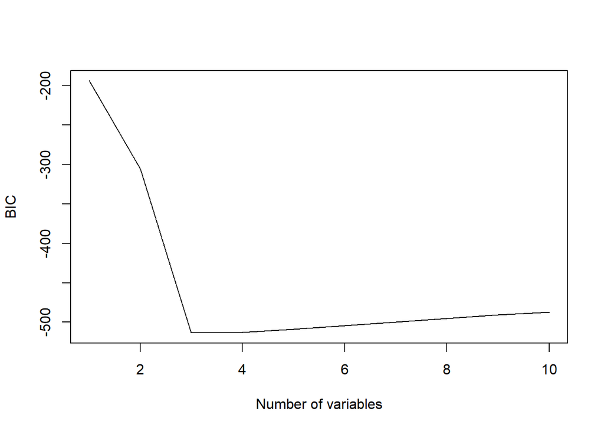

```r
plot(regFwdSum$bic, xlab = "Number of variables", ylab = "BIC", type = "l")
```

```r
plot(regFwdSum$adjr2, xlab = "Number of variables", ylab = "Adjusted R2", type = "l")
```

[output not shown]

```r
which.min(regFwdSum$cp)
```

```
## [1] 4
```

```r
which.min(regFwdSum$bic)
```

```
## [1] 3
```

```r
which.max(regFwdSum$adjr2)
```

```
## [1] 4
```

```r
regfitBwd <- regsubsets(Y~., data=DataSet, nvmax=10, method="backward")
regBwdSum <- summary(regfitBwd)
regBwdSum
```

```
## Subset selection object
## Call: regsubsets.formula(Y ~ ., data = DataSet, nvmax = 10, method = "backward")
## 10 Variables  (and intercept)
##     Forced in Forced out
## X       FALSE      FALSE
## X2      FALSE      FALSE
## X3      FALSE      FALSE
## X4      FALSE      FALSE
## X5      FALSE      FALSE
## X6      FALSE      FALSE
## X7      FALSE      FALSE
## X8      FALSE      FALSE
## X9      FALSE      FALSE
## X10     FALSE      FALSE
## 1 subsets of each size up to 10
## Selection Algorithm: backward
##           X   X2  X3  X4  X5  X6  X7  X8  X9  X10
## 1  ( 1 )  " " " " "*" " " " " " " " " " " " " " "
## 2  ( 1 )  " " "*" "*" " " " " " " " " " " " " " "
## 3  ( 1 )  "*" "*" "*" " " " " " " " " " " " " " "
## 4  ( 1 )  "*" "*" "*" " " " " " " " " " " "*" " "
## 5  ( 1 )  "*" "*" "*" " " " " " " " " "*" "*" " "
## 6  ( 1 )  "*" "*" "*" " " " " " " " " "*" "*" "*"
## 7  ( 1 )  "*" "*" "*" " " " " "*" " " "*" "*" "*"
## 8  ( 1 )  "*" "*" "*" "*" " " "*" " " "*" "*" "*"
## 9  ( 1 )  "*" "*" "*" "*" "*" "*" " " "*" "*" "*"
## 10  ( 1 ) "*" "*" "*" "*" "*" "*" "*" "*" "*" "*"
```

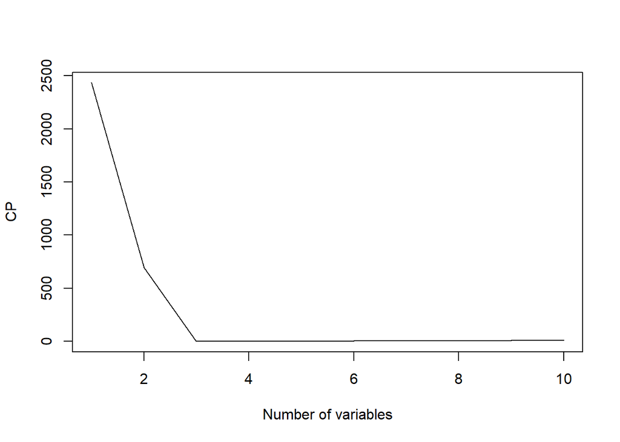

```r
plot(regBwdSum$cp, xlab = "Number of variables", ylab = "CP", type = "l")
```

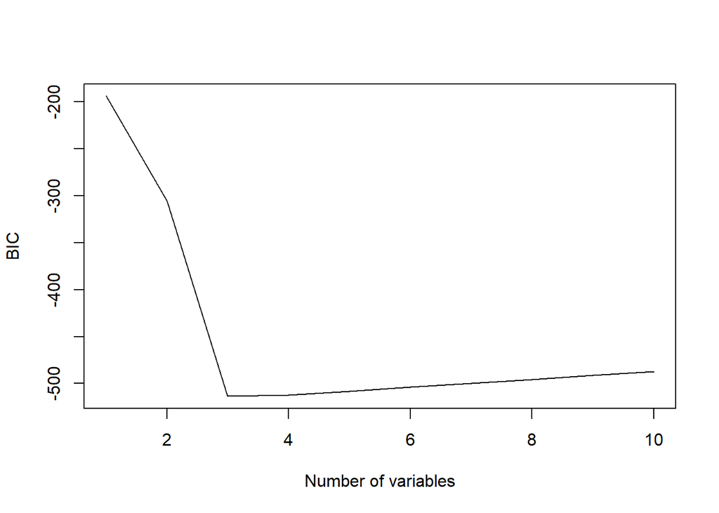

```r
plot(regBwdSum$bic, xlab = "Number of variables", ylab = "BIC", type = "l")
```

```r
plot(regBwdSum$adjr2, xlab = "Number of variables", ylab = "Adjusted R2", type = "l")
```

[output not shown]

```r
which.min(regBwdSum$cp)
```

```
## [1] 4
```

```r
which.min(regBwdSum$bic)
```

```
## [1] 3
```

```r
which.max(regBwdSum$adjr2)
```

```
## [1] 4
```

```r
coef(regfitBwd, id=3)
```

```
## (Intercept)           X          X2          X3
##    6.061507    4.975280    3.876209    3.017639
```

```r
coef(regfitBwd, id=4)
```

```
## (Intercept)           X          X2          X3          X9
## 6.079236362 5.231905828 3.833494180 2.819555807 0.001290827
```

4. The results are very similar when using forward or backwards stepwise selection as they were when using best subset. All of the model were optimized using 3 or 4 variables and they all included the correct variables in the results, and the extra variable not in the model had a coefficient very close to 0.

e)Fits a lasso model to the same data. Finds the optimal lambda value.

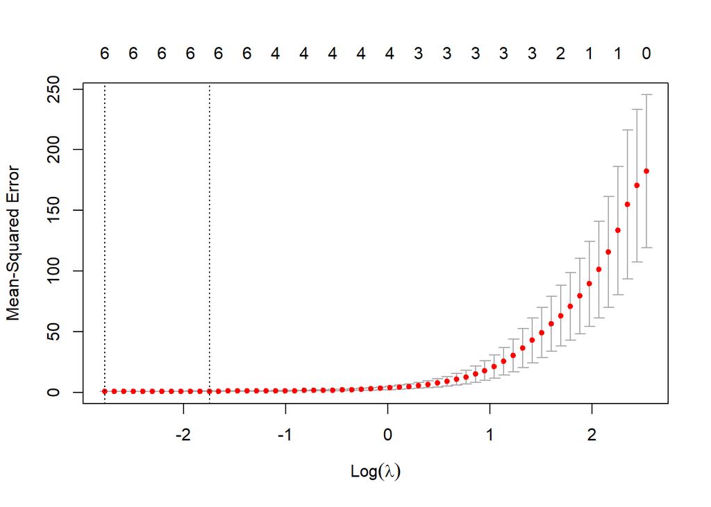

```r
X_matrix <- model.matrix(Y ~ ., data = DataSet)[, -1]
cv.lasso <- cv.glmnet(X_matrix, Y, alpha = 1)
plot(cv.lasso)
```

```r
bestlam <- cv.lasso$lambda.min
bestlam
```

```
## [1] 0.062534
```

```r
lassoPred <- glmnet(X_matrix, Y, alpha = 1)
predict(lassoPred, s = bestlam, type = "coefficients")
```

```
## 11 x 1 sparse Matrix of class "dgCMatrix"
##                      s1
## (Intercept) 6.173992049
## X           5.163314622
## X2          3.630728702
## X3          2.785628655
## X4          0.043080902
## X5          0.022936463
## X6          .
## X7          0.002832421
## X8          .
## X9          .
## X10         .
```

5. Lasso included a few more variables that did the other models, it chose to include 6. The coefficients for the intercept, x, x^2 and x^3 are all fairly close to the expected values used in the model that created the predictor varaibles. And the other varialbes x^4 to x^7 all have relatively low coefficients. The results are consistnt across all methods.
6. Generate a new reponse variables. I used the coefficents 20 and 9 for the intercept and x^7 coefficient respecitvely.

```r
Ynew <- 20 + 9*X^7+noise
Ynew
```

```
##   [1]    19.038860    20.042179    16.528514   256.805834    19.349211
##   [6]    19.514732    20.775541    21.986576    20.573004    21.679947
##  [11]   181.793809    19.550671    21.110871 -2332.701478    40.310074
##  [16]    19.607192    19.680007    25.725969    22.761251    20.057223
##  [21]    24.475727    22.954499    19.785421 -1089.925302    20.216132
##  [26]    20.712666    19.926416  -114.011299    19.266912    19.695777
##  [31]    96.984147    19.411104    20.543340    18.481606   -64.204118
##  [36]    18.444472    19.685690    19.471720    36.889191    21.300211
##  [41]    18.085611    21.175980    19.054000    19.685540    18.222322
##  [46]    18.450622    22.094872    21.442609    18.713697    22.070007
##  [51]    20.464451    19.691950    19.686769    -2.019414   130.203011
##  [56]  1094.183042    20.991924     7.201798    18.790909    21.869283
##  [61]  4167.765820    19.761353    21.726885    20.886423    18.252828
##  [66]    22.206179  -541.966473   149.269933    19.855618  2076.653330
##  [71]    22.357450    19.287674    20.742212    14.338294   -24.130197
##  [76]    19.966881    20.757366    22.075245    21.027393    20.985200
##  [81]    18.595592    20.983888    48.565420  -152.970760    20.755701
##  [86]    19.845328    35.276724    19.231749    19.578335    19.074763
##  [91]    19.698401    54.160139    44.766093    21.573147   246.806144
##  [96]    19.104537   -28.287626    18.801034   -16.761539    19.570968
```

```r
modelNew <- regsubsets(y = Ynew,
                    x = X_matrix,
                    nvmax = 10)

modelNewSum <- summary(modelNew)
modelNewSum
```

```
## Subset selection object
## 10 Variables  (and intercept)
##     Forced in Forced out
## X       FALSE      FALSE
## X2      FALSE      FALSE
## X3      FALSE      FALSE
## X4      FALSE      FALSE
## X5      FALSE      FALSE
## X6      FALSE      FALSE
## X7      FALSE      FALSE
## X8      FALSE      FALSE
## X9      FALSE      FALSE
## X10     FALSE      FALSE
## 1 subsets of each size up to 10
## Selection Algorithm: exhaustive
##           X   X2  X3  X4  X5  X6  X7  X8  X9  X10
## 1  ( 1 )  " " " " " " " " " " " " "*" " " " " " "
## 2  ( 1 )  " " "*" " " " " " " " " "*" " " " " " "
## 3  ( 1 )  " " "*" " " " " "*" " " "*" " " " " " "
## 4  ( 1 )  "*" "*" "*" " " " " " " "*" " " " " " "
## 5  ( 1 )  "*" "*" "*" "*" " " " " "*" " " " " " "
## 6  ( 1 )  "*" " " "*" " " " " "*" "*" "*" " " "*"
## 7  ( 1 )  "*" " " "*" " " "*" "*" "*" "*" " " "*"
## 8  ( 1 )  "*" "*" "*" "*" " " "*" "*" "*" " " "*"
## 9  ( 1 )  "*" "*" "*" "*" " " "*" "*" "*" "*" "*"
## 10  ( 1 ) "*" "*" "*" "*" "*" "*" "*" "*" "*" "*"
```

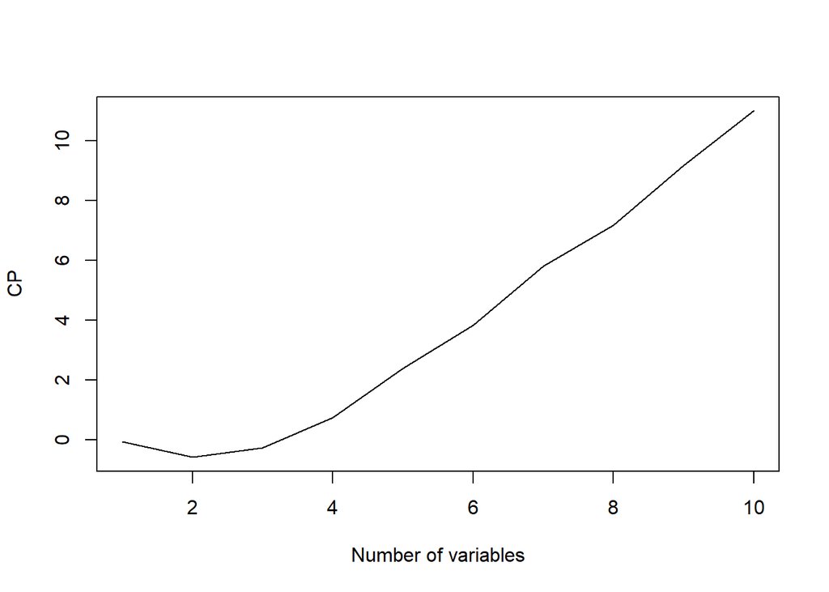

```r
plot(modelNewSum$cp, xlab = "Number of variables", ylab = "CP", type = "l")
```

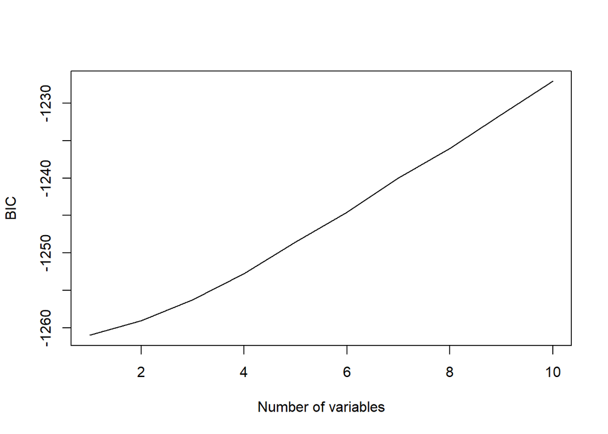

```r
plot(modelNewSum$bic, xlab = "Number of variables", ylab = "BIC", type = "l")
```

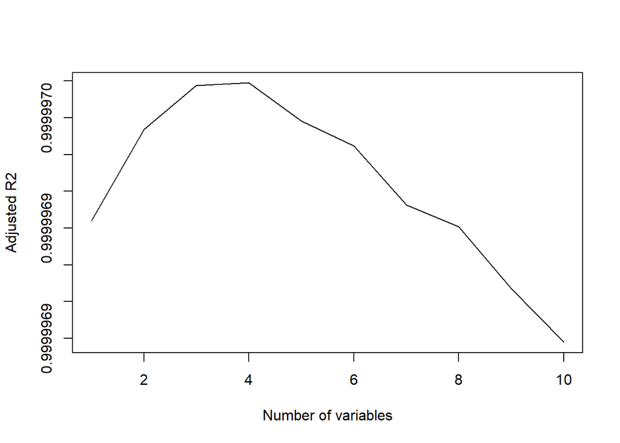

```r
plot(modelNewSum$adjr2, xlab = "Number of variables", ylab = "Adjusted R2", type = "l")
```

```r
which.min(modelNewSum$cp)
```

```
## [1] 2
```

```r
which.min(modelNewSum$bic)
```

```
## [1] 1
```

```r
which.max(modelNewSum$adjr2)
```

```
## [1] 4
```

```r
coef(modelNew, id = 2)
```

```
## (Intercept)          X2          X7
##  20.0704904  -0.1417084   9.0015552
```

```r
coef(modelNew, id = 1)
```

```
## (Intercept)          X7
##    19.95894     9.00077
```

```r
coef(modelNew, id = 4)
```

```
## (Intercept)           X          X2          X3          X7
##  20.0762524   0.2914016  -0.1617671  -0.2526527   9.0091338
```

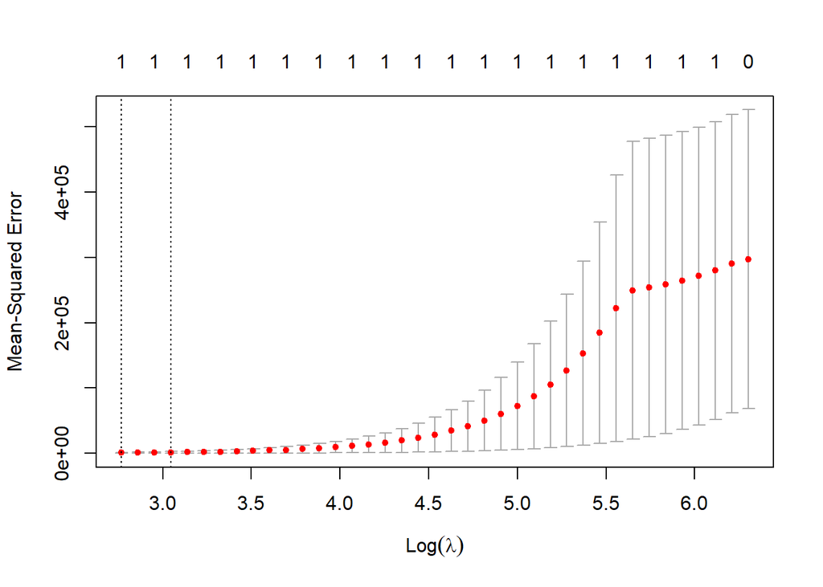

```r
X_matrix <- model.matrix(Ynew ~ ., data = DataSet)[, -1]
cvNew.lasso <- cv.glmnet(X_matrix, Ynew, alpha = 1)
plot(cvNew.lasso)
```

```r
bestlam <- cvNew.lasso$lambda.min
bestlam
```

```
## [1] 15.9024
```

```r
lassoPred <- glmnet(X_matrix, Ynew, alpha = 1)
predict(lassoPred, s = bestlam, type = "coefficients")
```

```
## 12 x 1 sparse Matrix of class "dgCMatrix"
##                    s1
## (Intercept) 21.066266
## X            .
## X2           .
## X3           .
## X4           .
## X5           .
## X6           .
## X7           8.738393
## X8           .
## X9           .
## X10          .
## Y            .
```

6. The best subset selection method resulted in models using 2,1,4 variables for the different measures CP, BIC, and AdjR2. All of them used the intercept and x^7 with values close tot he expected 20 and 9 and the other coefficients were all much closer to 0.  
   Lasso correctly only used the intercept and the x^7 variables but the values were a bit farther aways from the 20,9 expected values than the best subset selections methods were.